# Cofounding Variables Exploration with Wine Quality Dataset

Leah Nguyen

# Introduction

Confounding variables (also known as lurking variables) are essentially factors that affect both the dependent and independent variables. Failing to account for these confounders could lead to incorrect conclusions when doing analysis for the dataset.

To illustrate a basic example, I look at data concerned with a commodity that certainly had its share of consumption growth during the quarantine period: Wine.

# About the dataset

This excersise will assess confounding in the Wine quality Datasets taken from [Kaggle](https://www.kaggle.com/rajyellow46/wine-quality). The datset contains the chemical properties of red and white variants of the Portuguese “Vinho Verde” wine. These chemical properties play a vital role in determining the quality of Wine.

```r
winequalityN <- read_csv("winequalityN.csv")
```

The dataset contain 6,497 observations with 13 variables which indicate the Wine quality for both Red and White type. Here is some description about the data: - **type**: This column indicates the wine type, including red and white.

- **fixed.acidity**: This column is most acids involved with wine or fixed or nonvolatile.
- **volatile acidity**: The amount of acetic acid in wine which at this column is too high of levels can lead to an unpleasant. This means is wine contains the high vinegar taste.
- **citric acid**: When found in small quantities, citric acid can add ‘freshness’ and ‘flavor’ to wines.
- **residual sugar**: The amount of sugar remaining after fermentation stops. It’s rare to find wines with less than 1 gram/liter. Wines with greater than 45 grams/liter are considered sweet.
- **chlorides**: This column gives the amount of salt in the wine.
- **free sulfur dioxide**: The free form of SO2 exists in equilibrium between molecular SO2 (as a dissolved gas) and bisulfite ion; it prevents microbial growth and the oxidation of wine.
- **total sulfur dioxide**: Amount of free and bound forms of S02. This amount in low concentrations, SO2 is mostly undetectable in wine, but at free SO2 concentrations over 50 ppm, SO2 becomes evident in flavour of smell and taste of wine.
- **density**: This column gives the density. The density of water is close to that of water depending on the percent of sugar and alcohol content.
- **pH**: This column gives the amount of acid or wine basic. Describes how acidic or basic a wine is on a scale from 0 (very acidic) to 14 (very basic). Most of wines are between 3*4 on the pH scale.
- **sulphates**: This column gives the amount of sulphates of contains in wine. A wine additive which can contribute to sulphur dioxide gas (S02) levels, which acts as an antimicrobial and antioxidant.
- **alcohol**: This column gives the amount the percent content of alcohol in the wine.
- **quality**: This column gives the quality of the wine. Output variable; based on sensory data, scores between 0 and 10. This means, 0 is poor quality and 10 is high quality.

# The approach

In order to assessing the cofounding variables in this dataset, I have come up with 2 different approaches:

1. **Assumption Approach**: My personal assumptions about correlation of Wine quality.
2. **Correlation Matrix**: Using correlation matrix to identify which variables are highly correlated to each other.

# Assumption Approach

## The lower the sugar, the better the wine?

By plotting ‘wine quality’ with ‘residual sugar’, I find out that as sweetness level goes up, the quality of the wine actually diminishes.

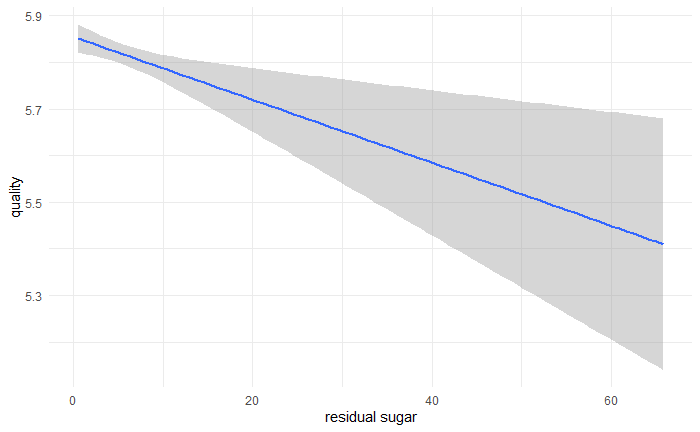

Before I readily assume that wine drinkers would always prefer liquor that’s completely devoid of sweetness, I first have to consider if there are confounding variables that would affect my analysis.

An obvious one that’s available in my dataset is of course the type of wine.

## White Wine vs Red Wine

If I produce the same plot but split by the type of wine, I discover that my premature conclusion is incorrect. It turns out that perception of quality *improves* with sweetness for red wine, while the inverse is true only for white wine.

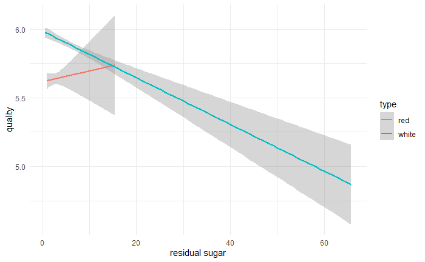

# Correlation Variables

The quality variable has been converted from numeric to Categorical data type as per the below mentioned conversion standard :

- Quality 3-4 : Poor
- Quality 5-6 : Average
- Quality 7-9 : Good

```r
winequalityN$quality <- ifelse(winequalityN$quality <= 4, "Poor",
ifelse(winequalityN$quality <= 6, "Average", "Good"))
```

## Sulphates - PH

The below plot shows that Sulphates and PH have a positive correlation. It can be seen that as the Sulphates increases the PH value also increases.

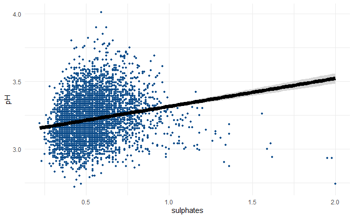

Further grouping by wine quality also shows the same positive correlation being maintained across all levels of wine quality.

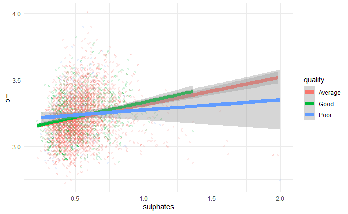

Howevever on further grouping by wine type, it can be seen that white wine still maintains a positive correlation between Sulphates and PH across all quality levels, but red wine has a negative relationship as PH decreases with increase in Suplahtes for all quality levels.

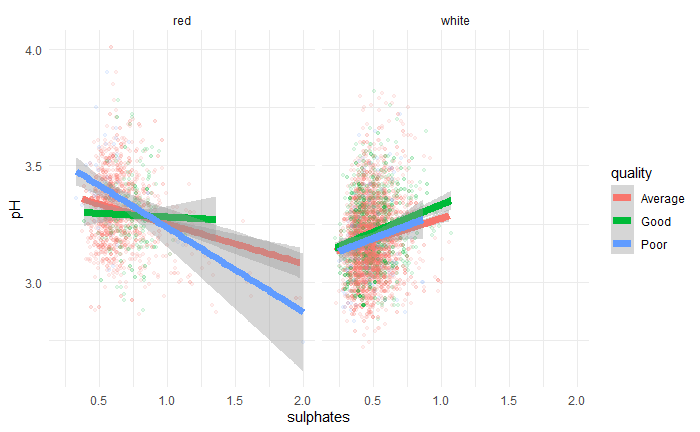

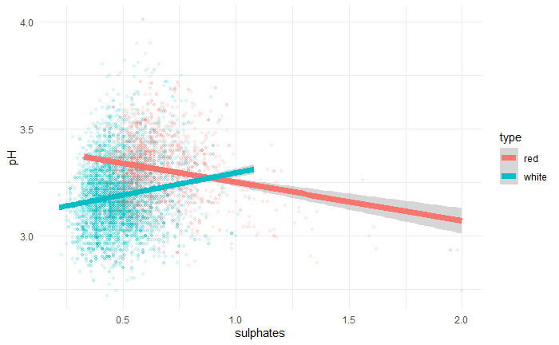

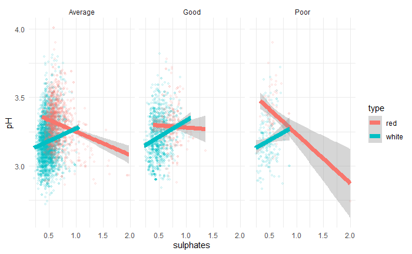

## Residual Sugar - Alcohol

The below plot shows that Residual Sugar and Alcohol have a negative correlation. It can be seen that as the residual sugar increases the alcohol decreases.

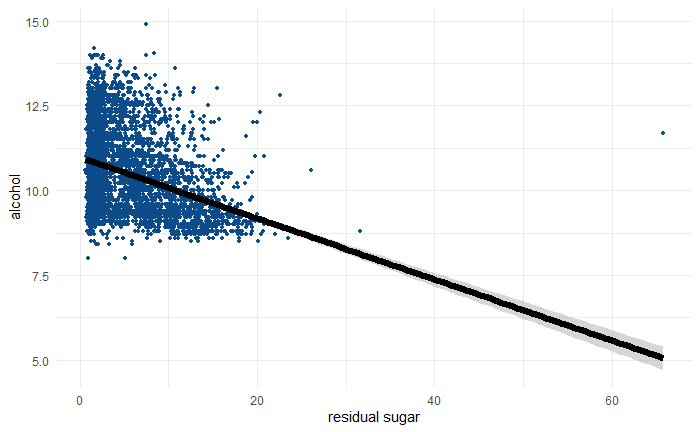

After taking into account the wine type and quality, I observe the below changes in the relationship:

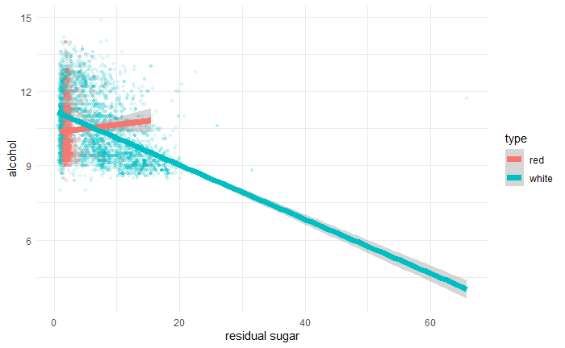

## Density - Total Sulfur Dioxide

On further grouping the wine types by wine quality levels, shows that white wine maintains a positive relation between density and total sulfur dioxide across all quality levels, however red wine maintains a positive collinearity for Poor and average quality levels whereas for Good quality level the correlation is negative as total sulfur dioxide decreases with increase in density.

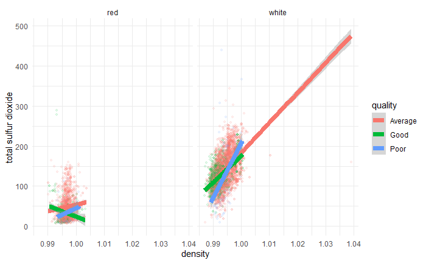

# Conclusion

In the above data analysis, Wine quality levels and wine type have been identified as confounding variables as they change the correlation(results) between different chemical properties by introducing bias and increasing variance when considered. Thus when woking on multivariate relationships it is important to identify and consider these variables when modelling.